# Práctica 2. Visualización de Datos

### **Ejercicio 4**

- Carga el fichero `Ejercicio4_Data.Rdata`. Examina las variables que tiene dicho dataset.
- Representa un gráfico de puntos, en el que se muestre la fecha en el eje $x$ y las ventas en el eje $y$. Queremos que los datos de cada fabricante sean de un color distinto. ¿Es este gráfico valido para evaluar la evolución de las ventas de cada fabricante?
- Representa un gráfico como el anterior en el que se muestre la línea que une los puntos que antes has representado.
- Modifica el gráfico anterior para que la tendencia de cada fabricante este trazada con un tipo de línea diferente.
- Añade el siguiente título al gráfico *“Ventas mensuales de diferentes compañías tecnológicas”*.
- Almacena en formato **pdf** el gráfico resultante en un fichero denominado `Ejercicio4.pdf`.

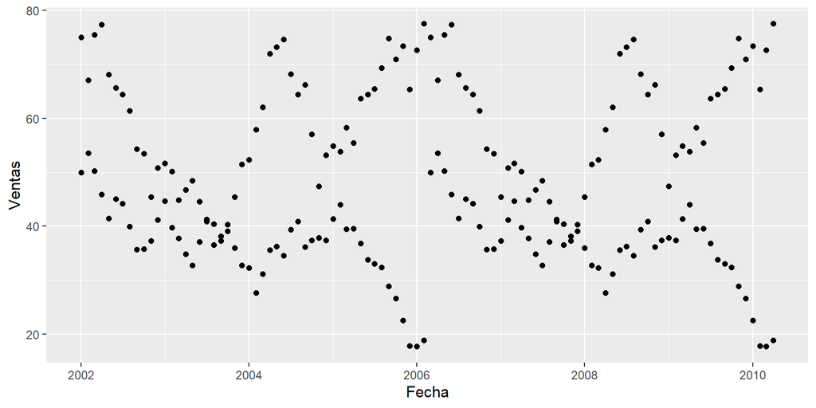

```r
fname <- './data/Ejercicio4_Data.Rdata'
load(fname) # Guardado como DatosEjer4

ej4 <- ggplot(DatosEjer4, aes(x=Fecha, y=Ventas)) + geom_point() # No es valido para evaluar la evolución.
ej4
```

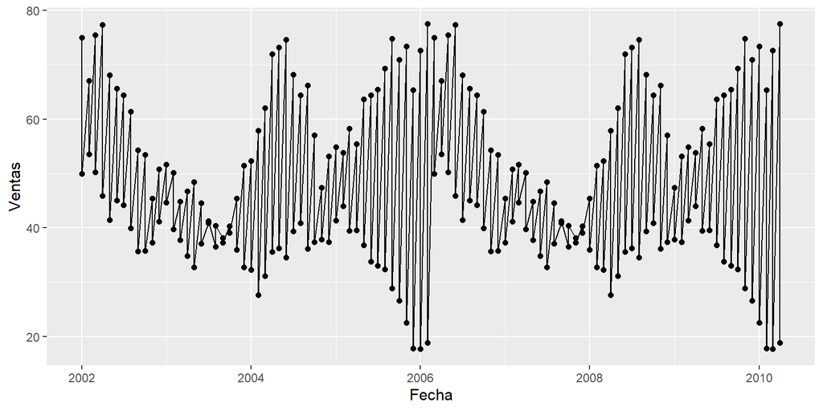

```r
ej4 <- ggplot(DatosEjer4, aes(x=Fecha, y=Ventas)) +
        geom_point() +
        geom_line()
ej4
```

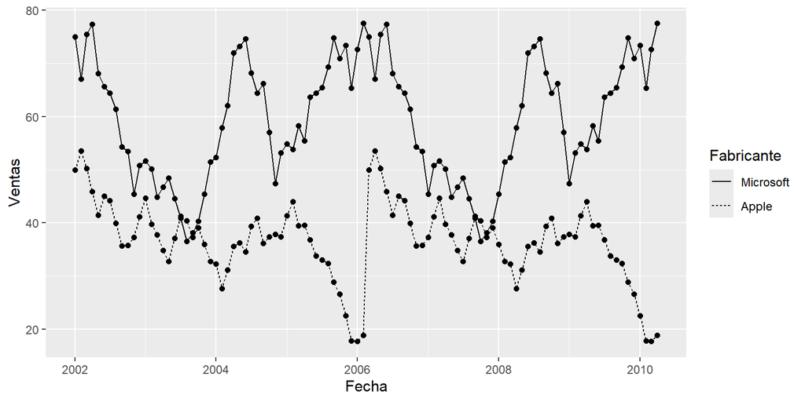

```r
ej4 <- ggplot(DatosEjer4, aes(x=Fecha, y=Ventas, group = Fabricante)) +
        geom_point() +
        geom_line(aes(linetype= Fabricante))
ej4
```

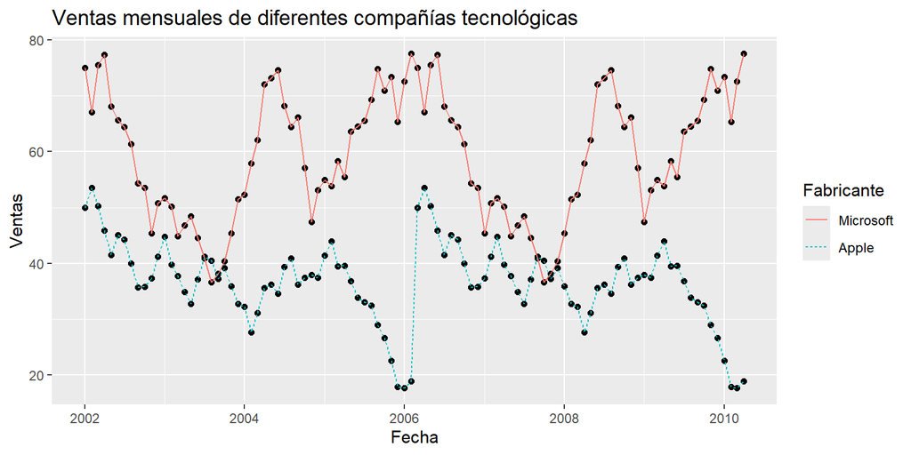

```r
ej4 <- ggplot(DatosEjer4, aes(x=Fecha, y=Ventas, group = Fabricante)) +
        geom_point() +
        geom_line(aes(linetype= Fabricante, color= Fabricante)) +
        labs(title = 'Ventas mensuales de diferentes compañías tecnológicas')
ej4
```

```r
gname <- ('./figure/Ejercicio4.pdf')
ggsave(gname, ej4)
```

## Barras de error con **ggplot2**

En un gráfico de línea podemos añadir también barras de error. Para ver de lo que estamos hablando cargamos el fichero `ExperimentoEjemplo.Rdata`. Fíjate en cómo se calculan y añaden las barras de error. Del mismo modo, este ejemplo es interesante para ver otra forma de añadir títulos y etiquetas en los ejes mediante la función **labs()**. ¿Podemos inferir qué hace el argumento **position_dodge(0.05)** de la función **geom_errorbar()**?

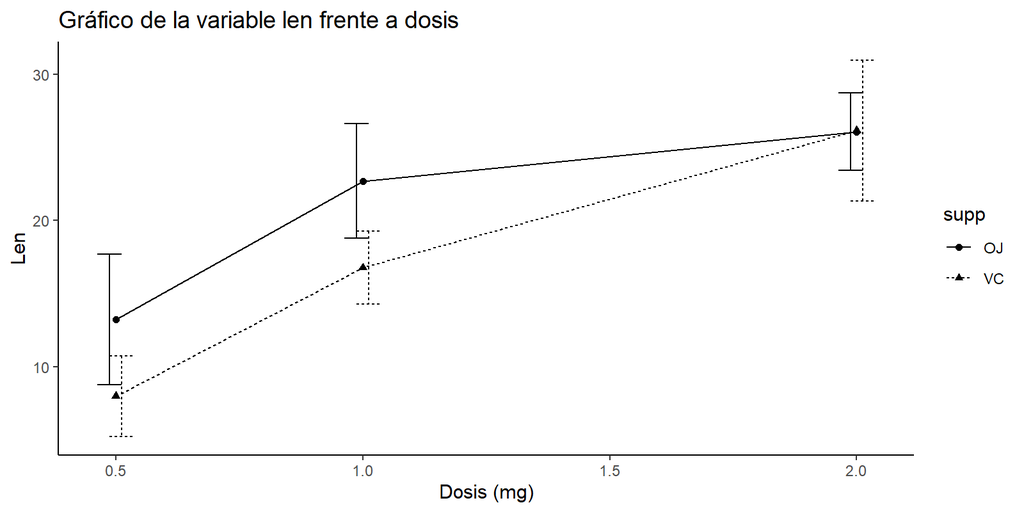

```r
load("./data/ExperimentoEjemplo.Rdata")
# Un gráfico simple
# Podemos cambiar los tipos de línea y la forma de los puntos por grupos.
ggplot(df3, aes(x=dose, y=len, group = supp, shape=supp, linetype=supp))+
    geom_errorbar(aes(ymin=len-sd, ymax=len+sd), width=.1, position=position_dodge(0.05)) +
    geom_line() +
    geom_point()+
    labs(title="Gráfico de la variable len frente a dosis",x="Dosis (mg)", y = "Len")+
    theme_classic()
```

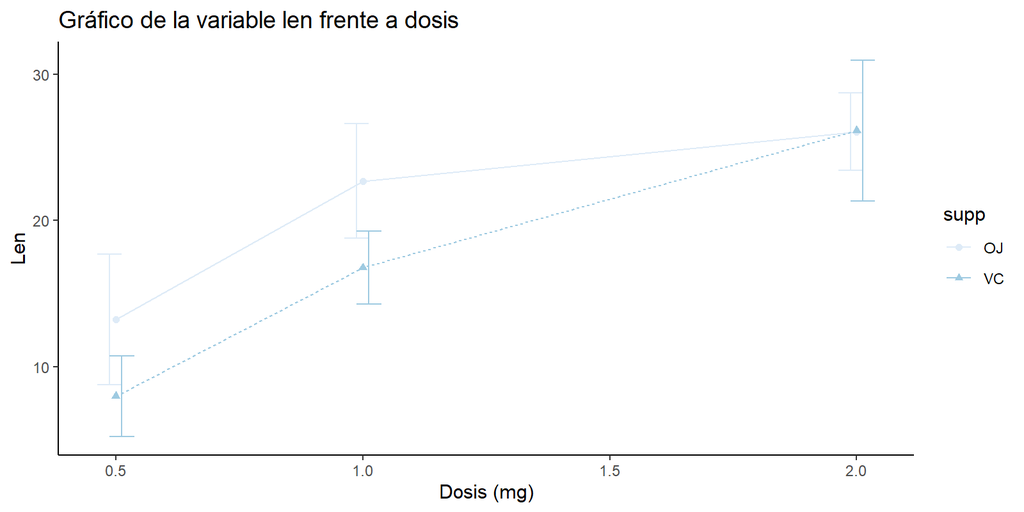

```r
# Si no nos gustan los colores... los podemos cambiar...
# y añadir barras de error
p <- ggplot(df3, aes(x=dose, y=len, group = supp, color=supp))+
    geom_errorbar(aes(ymin=len-sd, ymax=len+sd), width=.1,
    position=position_dodge(0.05)) +
    geom_line(aes(linetype=supp)) +
    geom_point(aes(shape=supp))+
    labs(title="Gráfico de la variable len frente a dosis",x="Dosis (mg)", y = "Len") +
    theme_classic()
p + theme_classic() + scale_color_brewer(palette="Blues")
```

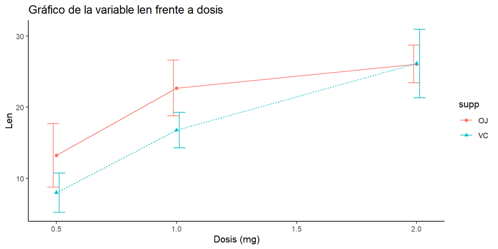

```r
p
```

### **Ejercicio 5**

Añadir barras de error a un gráfico de línea.

- Carga el fichero `Experimento.Rdata`. Examina las variables que tiene dicho dataset.
- Representa un gráfico de puntos, en la que se muestre la `Dosis` en el eje $x$ y la `Altura` en el eje $y$. Queremos que los datos de cada `Complemento` se represente en una línea diferente con diferentes trazos. Hazlo incluyendo las opciones de tipo de línea y forma del punto dentro del **aes()** de la capa **ggplot**.
- Crea otro gráfico a partir de añadir al gráfico anterior barras de error a cada punto. El error viene dado por la variable `Error_Altura`.
- Crea otro gráfico, como el anterior (**idéntico**), pero en este caso no puedes incluir el tipo de línea y el tipo de punto en el aes() de la capa ggplot. Además queremos que la paleta de colores sea en tonos de azules.
- Almacena en formato **pdf** el gráfico resultante en un fichero denominado `Ejercicio5.pdf`.

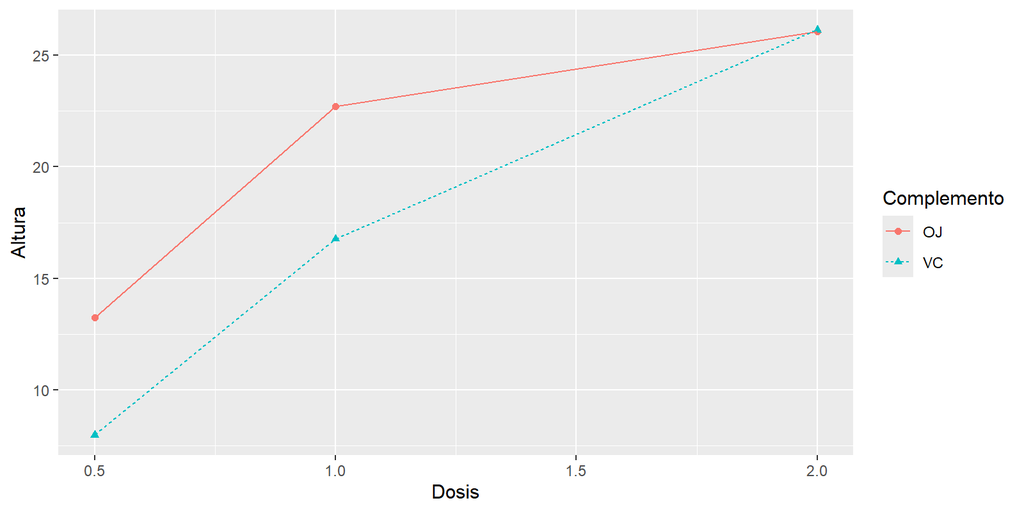

```r
fname <- './data/Experimento.Rdata'
load(fname) # Guardado como Experimento

exp <- ggplot(Experimento, aes(x=Dosis, y=Altura, group=Complemento)) +
        geom_point(aes(shape= Complemento, color= Complemento)) +
        geom_line(aes(linetype= Complemento, color= Complemento))
exp
```

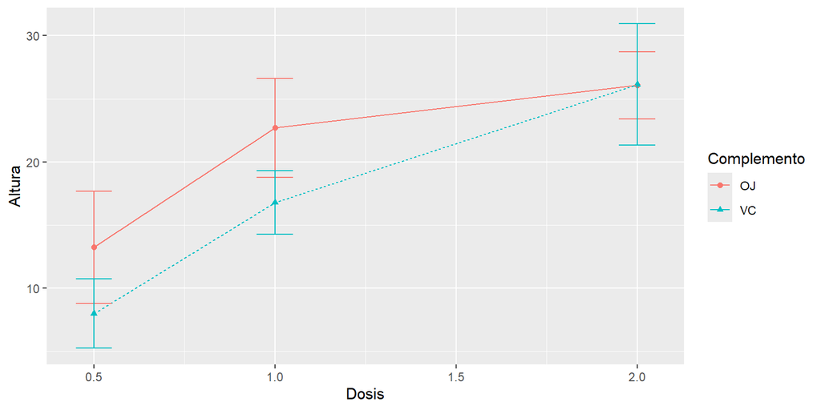

```r
exp <- ggplot(Experimento, aes(x=Dosis, y=Altura, group=Complemento)) +
        geom_point(aes(shape= Complemento, color= Complemento)) +
        geom_line(aes(linetype= Complemento, color= Complemento)) +
        geom_errorbar(aes(ymin = Altura - Error_Altura, ymax = Altura + Error_Altura, color = Complemento), width = .1)
exp
```

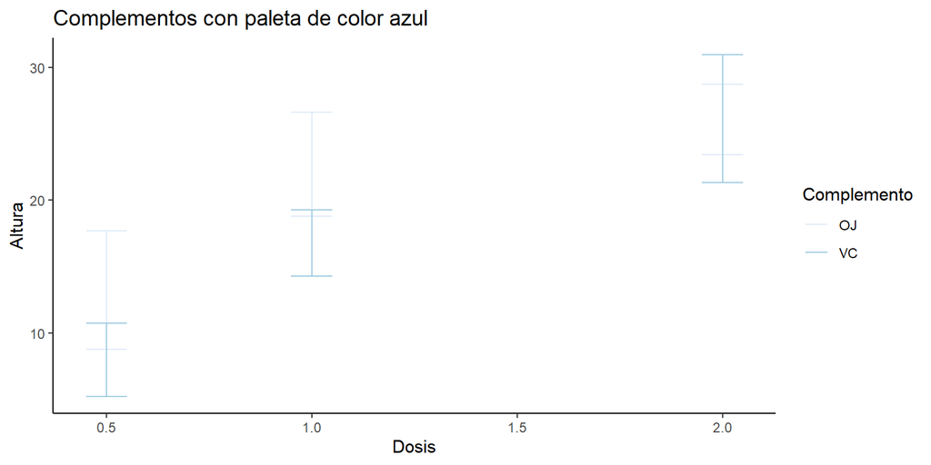

```r
exp <- ggplot(Experimento, aes(x=Dosis, y=Altura, group=Complemento)) +
        geom_errorbar(aes(ymin = Altura - Error_Altura, ymax = Altura + Error_Altura, color = Complemento), width = .1) +
        theme_classic() +
        scale_color_brewer(palette='Blues') +
        labs(title= 'Complementos con paleta de color azul')
exp
```

```r
gname <- ('./figure/Ejercicio5.pdf')
ggsave(gname, exp)
```